# Practical ML Project

Mario Sobhy

August 5, 2017

# Executive Summary

Using devices such as Jawbone Up, Nike FuelBand, and Fitbit it is now possible to collect a large amount of data about personal activity relatively inexpensively. These type of devices are part of the quantified self movement – a group of enthusiasts who take measurements about themselves regularly to improve their health, to find patterns in their behavior, or because they are tech geeks. One thing that people regularly do is quantify how much of a particular activity they do, but they rarely quantify how well they do it. In this project, your goal will be to use data from accelerometers on the belt, forearm, arm, and dumbell of 6 participants. They were asked to perform barbell lifts correctly and incorrectly in 5 different ways. More information is available from the website [here](http://groupware.les.inf.puc-rio.br/har) (see the section on the Weight Lifting Exercise Dataset).

### Loading Data

```r
##  Load|Dataset
#Train Data
data.raw <- read.csv("./data/pml-training.csv",header = TRUE, na.strings = c ("","NA"))
#Test Data
data.test <- read.csv("./data/pml-testing.csv",header = TRUE,na.strings = c ("","NA"))
```

### Take a peek into the data

```r
##  Load|Dataset
dim(data.raw)    # Dimension
```

```
## [1] 19622   160
```

```r
names(data.raw) # Names
```

```
##   [1] "X"                        "user_name"
##   [3] "raw_timestamp_part_1"     "raw_timestamp_part_2"
##   [5] "cvtd_timestamp"           "new_window"
##   [7] "num_window"               "roll_belt"
##   [9] "pitch_belt"               "yaw_belt"
##  [11] "total_accel_belt"         "kurtosis_roll_belt"
##  [13] "kurtosis_picth_belt"      "kurtosis_yaw_belt"
##  [15] "skewness_roll_belt"       "skewness_roll_belt.1"
##  [17] "skewness_yaw_belt"        "max_roll_belt"
##  [19] "max_picth_belt"           "max_yaw_belt"
##  [21] "min_roll_belt"            "min_pitch_belt"
##  [23] "min_yaw_belt"             "amplitude_roll_belt"
##  [25] "amplitude_pitch_belt"     "amplitude_yaw_belt"
##  [27] "var_total_accel_belt"     "avg_roll_belt"
##  [29] "stddev_roll_belt"         "var_roll_belt"
```

[output cut: 65 more lines]

```r
str(data.raw)   # Structure
```

```
## 'data.frame':    19622 obs. of  160 variables:
##  $ X                       : int  1 2 3 4 5 6 7 8 9 10 ...
##  $ user_name               : Factor w/ 6 levels "adelmo","carlitos",..: 2 2 2 2 2 2 2 2 2 2 ...
##  $ raw_timestamp_part_1    : int  1323084231 1323084231 1323084231 1323084232 1323084232 1323084232 1323084232 1323084232 1323084232 1323084232 ...
##  $ raw_timestamp_part_2    : int  788290 808298 820366 120339 196328 304277 368296 440390 484323 484434 ...
##  $ cvtd_timestamp          : Factor w/ 20 levels "02/12/2011 13:32",..: 9 9 9 9 9 9 9 9 9 9 ...
##  $ new_window              : Factor w/ 2 levels "no","yes": 1 1 1 1 1 1 1 1 1 1 ...
##  $ num_window              : int  11 11 11 12 12 12 12 12 12 12 ...
##  $ roll_belt               : num  1.41 1.41 1.42 1.48 1.48 1.45 1.42 1.42 1.43 1.45 ...
##  $ pitch_belt              : num  8.07 8.07 8.07 8.05 8.07 8.06 8.09 8.13 8.16 8.17 ...
##  $ yaw_belt                : num  -94.4 -94.4 -94.4 -94.4 -94.4 -94.4 -94.4 -94.4 -94.4 -94.4 ...
##  $ total_accel_belt        : int  3 3 3 3 3 3 3 3 3 3 ...
##  $ kurtosis_roll_belt      : Factor w/ 396 levels "0.000673","0.005503",..: NA NA NA NA NA NA NA NA NA NA ...
##  $ kurtosis_picth_belt     : Factor w/ 316 levels "0.006078","-0.021887",..: NA NA NA NA NA NA NA NA NA NA ...
##  $ kurtosis_yaw_belt       : Factor w/ 1 level "#DIV/0!": NA NA NA NA NA NA NA NA NA NA ...
```

[output cut: 86 more lines]

There is a large number of variables that can be considered id’s, for example **timestamp** and **user name**. In my opinion they should not be used to model, the objective is to use the measures in the data set to predict the quality of the fisical exercises.

Lets partition the dataset in training and test dataset. The **createDataPartition** function form the caret package uses the class factors to do random sample using the diferent classes and preserve the overall class distribution of the data.

```r
library(caret)
set.seed(998)
inTraining <- createDataPartition(data.raw$classe, p = 0.75, list = FALSE)
training <- data.raw[inTraining, ]
testing <- data.raw[-inTraining, ]
```

A nice way to keep track of the variables that we don’t need is to create a vector and store the variables we want to **ignore**.

```r
ids <- c("X","cvtd_timestamp","user_name","raw_timestamp_part_1","raw_timestamp_part_2")

#Vector of variables you want to ignore
ignore<-NULL
ignore<-union(ignore,ids)
```

As it can be seen when we look in to the structure of the data, there are several variables is all intances missing. Let us see if somes variables have all observations missing.

```r
#All data Missing- if you look at the str output some will apear to be missing
vars<-names(training)
mvc<-sapply(training[vars],function(x)sum(is.na(x)))
mvn<- names(which(mvc==nrow(training)))
mvn
```

```
## character(0)
```

There’s no variable with all the observations missing, so lets look at the missing data using the library “Amelia” and a nice **missing plot**.

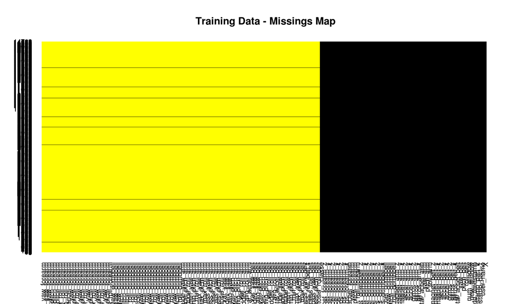

```r
library(Amelia)
missmap(training, main=" Training Data - Missings Map", col=c("yellow", "black"), legend=FALSE)
```

Using this map we can see there is a lot of variables with many missing instances, lets remove the features with many missing values (> 70%).

```r
mvn<-names(which(mvc>=0.7*nrow(training))) #removing variables with more than 70% of missings
mvn
```

```
##   [1] "kurtosis_roll_belt"       "kurtosis_picth_belt"
##   [3] "kurtosis_yaw_belt"        "skewness_roll_belt"
##   [5] "skewness_roll_belt.1"     "skewness_yaw_belt"
##   [7] "max_roll_belt"            "max_picth_belt"
##   [9] "max_yaw_belt"             "min_roll_belt"
##  [11] "min_pitch_belt"           "min_yaw_belt"
##  [13] "amplitude_roll_belt"      "amplitude_pitch_belt"
##  [15] "amplitude_yaw_belt"       "var_total_accel_belt"
##  [17] "avg_roll_belt"            "stddev_roll_belt"
##  [19] "var_roll_belt"            "avg_pitch_belt"
##  [21] "stddev_pitch_belt"        "var_pitch_belt"
##  [23] "avg_yaw_belt"             "stddev_yaw_belt"
##  [25] "var_yaw_belt"             "var_accel_arm"
##  [27] "avg_roll_arm"             "stddev_roll_arm"
##  [29] "var_roll_arm"             "avg_pitch_arm"
```

[output cut: 35 more lines]

```r
ignore<-union(ignore,mvn)
```

There is two variables that are related to the time stamp. I chose to remove **new_window** and **num_window**, they seam more of a artifact of the data collection method then a true feature for this classification problem. We can always try to use them if the final modeling results are weak.

```r
#Treating factor variables
others.to.ignore<-c("new_window","num_window")
ignore<-union(ignore,others.to.ignore )
```

Now we have a vector of the variables we want to **remove**, so lets clean our data…

```r
vars.keep<-setdiff(vars, ignore)
data.clean <- training[,vars.keep]
```

and see our missing data again using the Amelia package.

```r
library(Amelia)
```

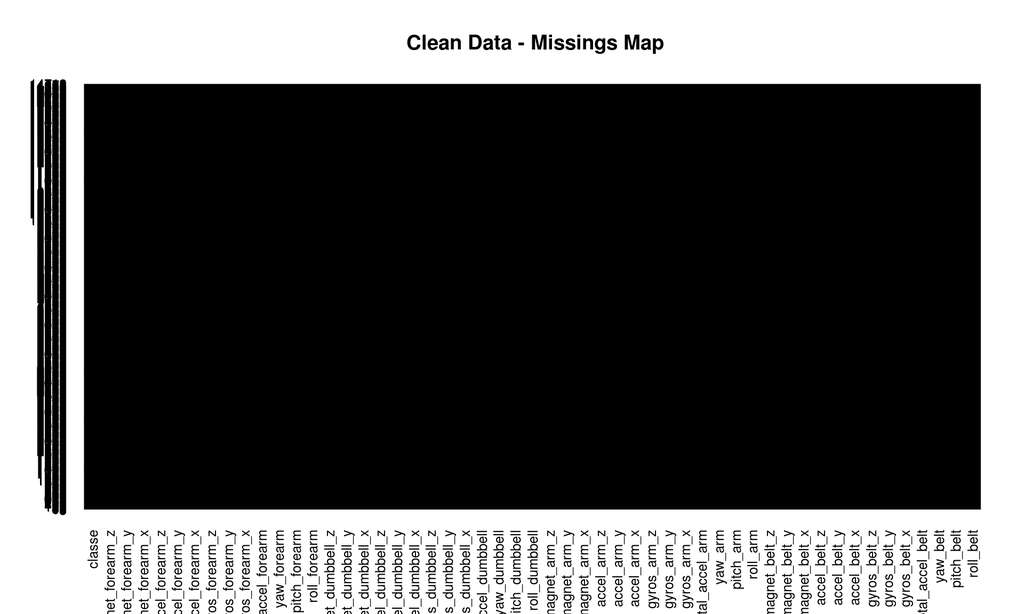

```r
missmap(data.clean, main=" Clean Data - Missings Map", col=c("yellow", "black"), legend=FALSE)
```

Now it looks very clean, lets look again at the structure of this data set.

```r
##  Load|Dataset
dim(data.clean)    # Dimension
```

```
## [1] 14718    53
```

```r
names(data.clean) # Names
```

```
##  [1] "roll_belt"            "pitch_belt"           "yaw_belt"
##  [4] "total_accel_belt"     "gyros_belt_x"         "gyros_belt_y"
##  [7] "gyros_belt_z"         "accel_belt_x"         "accel_belt_y"
## [10] "accel_belt_z"         "magnet_belt_x"        "magnet_belt_y"
## [13] "magnet_belt_z"        "roll_arm"             "pitch_arm"
## [16] "yaw_arm"              "total_accel_arm"      "gyros_arm_x"
## [19] "gyros_arm_y"          "gyros_arm_z"          "accel_arm_x"
## [22] "accel_arm_y"          "accel_arm_z"          "magnet_arm_x"
## [25] "magnet_arm_y"         "magnet_arm_z"         "roll_dumbbell"
## [28] "pitch_dumbbell"       "yaw_dumbbell"         "total_accel_dumbbell"
## [31] "gyros_dumbbell_x"     "gyros_dumbbell_y"     "gyros_dumbbell_z"
## [34] "accel_dumbbell_x"     "accel_dumbbell_y"     "accel_dumbbell_z"
## [37] "magnet_dumbbell_x"    "magnet_dumbbell_y"    "magnet_dumbbell_z"
## [40] "roll_forearm"         "pitch_forearm"        "yaw_forearm"
## [43] "total_accel_forearm"  "gyros_forearm_x"      "gyros_forearm_y"
## [46] "gyros_forearm_z"      "accel_forearm_x"      "accel_forearm_y"
## [49] "accel_forearm_z"      "magnet_forearm_x"     "magnet_forearm_y"
## [52] "magnet_forearm_z"     "classe"
```

## Looking into correlations

In the caret package there is some functions to help us find correlations between the variables.

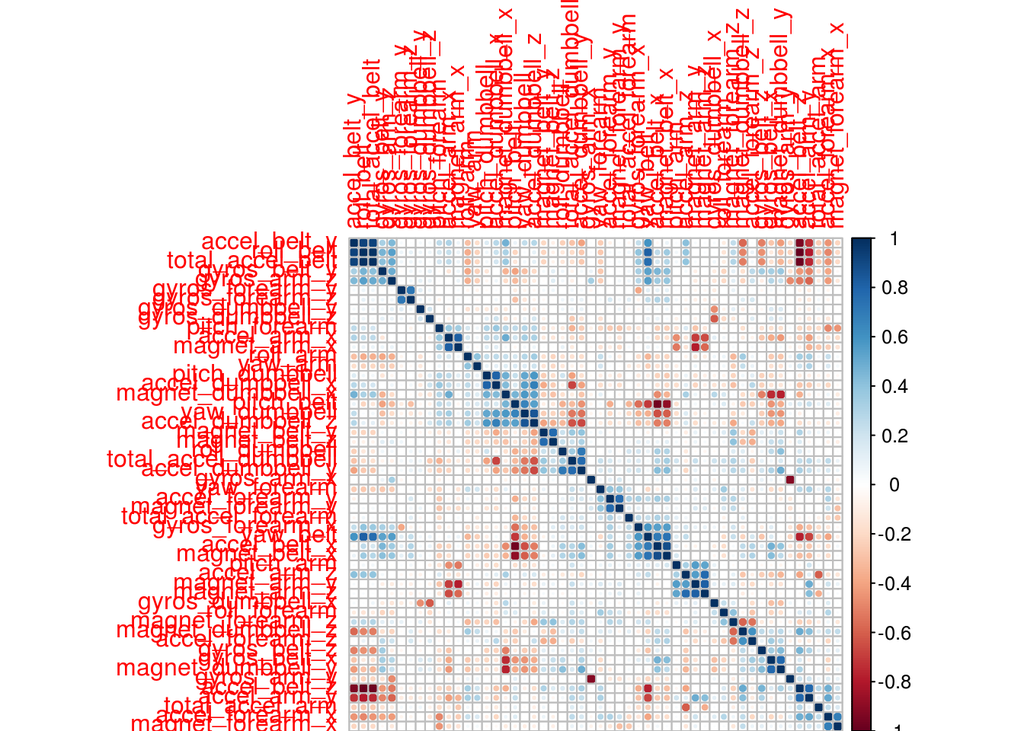

```r
library(corrplot)
correlations <- cor(data.clean[,-c(53)])
corrplot(correlations, order = "hclust")
```

```r
library(caret)
highCorr <- findCorrelation(correlations, cutoff = .75)
```

and then remove this variables from the data set.

```r
names(data.clean)[highCorr]
```

```
##  [1] "accel_belt_z"      "roll_belt"         "accel_belt_y"
##  [4] "accel_arm_y"       "total_accel_belt"  "accel_dumbbell_z"
##  [7] "accel_belt_x"      "pitch_belt"        "magnet_dumbbell_x"
## [10] "accel_dumbbell_y"  "magnet_dumbbell_y" "accel_dumbbell_x"
## [13] "accel_arm_x"       "accel_arm_z"       "magnet_arm_y"
## [16] "magnet_belt_z"     "accel_forearm_y"   "gyros_arm_x"
```

```r
ignore<-union(ignore,names(data.clean)[highCorr])
vars.keep<-setdiff(vars, ignore)
data.clean2 <- training[,vars.keep]
```

Done with cleaning.

## Building Machine Learning algoritm

First we define the type of cross-validation we want to use. This is a relatively big data set, we shall use the 10-fold cross-validation.

```r
library(caret)
ctrl <- trainControl(## 10-fold CV
                           method = "repeatedcv",
                           number = 10,
                           ## repeated ten times
                           repeats = 5,
                     classProbs = TRUE,
                     savePredictions = TRUE)
```

In our random forest the tuning parameter is the number of features randomly selected to create each tree. In the caret package the tunning parameter is named **mtry**.

```r
mtryValues <- c(1,2,3,4,5,10,20,32)
```

Now lets set up a seed and create a model using the train function from the caret package.

```r
set.seed(998)
rfFit <- train(x = data.clean2[,-c(35)],
               y = data.clean2$classe,
               method = "rf",
               ntree = 100,
               tuneGrid = data.frame(mtry = mtryValues),
               importance = TRUE,
               trControl = ctrl)
rfFit
```

```
## Random Forest
##
## 14718 samples
##    34 predictors
##     5 classes: 'A', 'B', 'C', 'D', 'E'
##
## No pre-processing
## Resampling: Cross-Validated (10 fold, repeated 5 times)
## Summary of sample sizes: 13244, 13245, 13248, 13247, 13246, 13246, ...
## Resampling results across tuning parameters:
##
##   mtry  Accuracy   Kappa
##    1    0.9858677  0.9821175
##    2    0.9909227  0.9885158
##    3    0.9912894  0.9889803
##    4    0.9918738  0.9897198
##    5    0.9922815  0.9902360
##   10    0.9916569  0.9894456
##   20    0.9899854  0.9873310
##   32    0.9827964  0.9782365
##
## Accuracy was used to select the optimal model using  the largest value.
## The final value used for the model was mtry = 5.
```

Now the plot of the accuracy of our model using cross-validation.

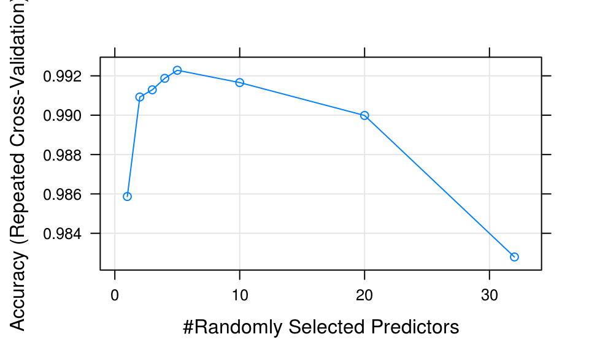

```r
plot(rfFit)
```

Lets try to look at the most important features:

```r
library(caret)
rfImp <- varImp(rfFit, scale = FALSE)
rfImp
```

```
## rf variable importance
##
##   variables are sorted by maximum importance across the classes
##   only 20 most important variables shown (out of 34)
##
##                           A     B     C     D     E
## yaw_belt             27.904 24.73 23.21 28.00 20.71
## roll_dumbbell        15.247 18.27 27.82 20.52 18.22
## magnet_dumbbell_z    25.704 26.33 27.67 21.68 20.97
## magnet_belt_y        21.798 22.42 23.42 23.77 25.01
## pitch_forearm        17.118 20.23 21.53 19.82 19.33
## roll_arm             13.888 20.43 17.92 19.61 16.51
## gyros_dumbbell_y     12.648 16.34 19.74 14.09 13.69
## gyros_arm_y          10.190 19.70 17.71 17.52 14.88
## roll_forearm         14.347 14.95 19.07 13.54 14.42
## total_accel_dumbbell 14.934 18.72 16.36 16.28 17.37
## magnet_belt_x        11.536 18.28 13.67 12.63 18.11
## gyros_belt_z         14.867 18.27 16.78 16.83 17.74
## gyros_forearm_y      10.489 17.92 14.84 15.47 15.22
## magnet_forearm_z     14.514 17.13 14.58 17.75 16.50
## yaw_arm              13.825 17.65 13.86 17.34 13.58
## magnet_arm_x         12.672 14.21 14.72 17.14 12.13
## total_accel_forearm  11.919 16.98 14.85 12.60 15.03
## total_accel_arm       7.017 16.32 12.22 12.81 14.98
## yaw_dumbbell         12.329 15.86 15.73 14.26 15.87
## gyros_forearm_z       9.953 15.58 11.27 12.03 10.61
```

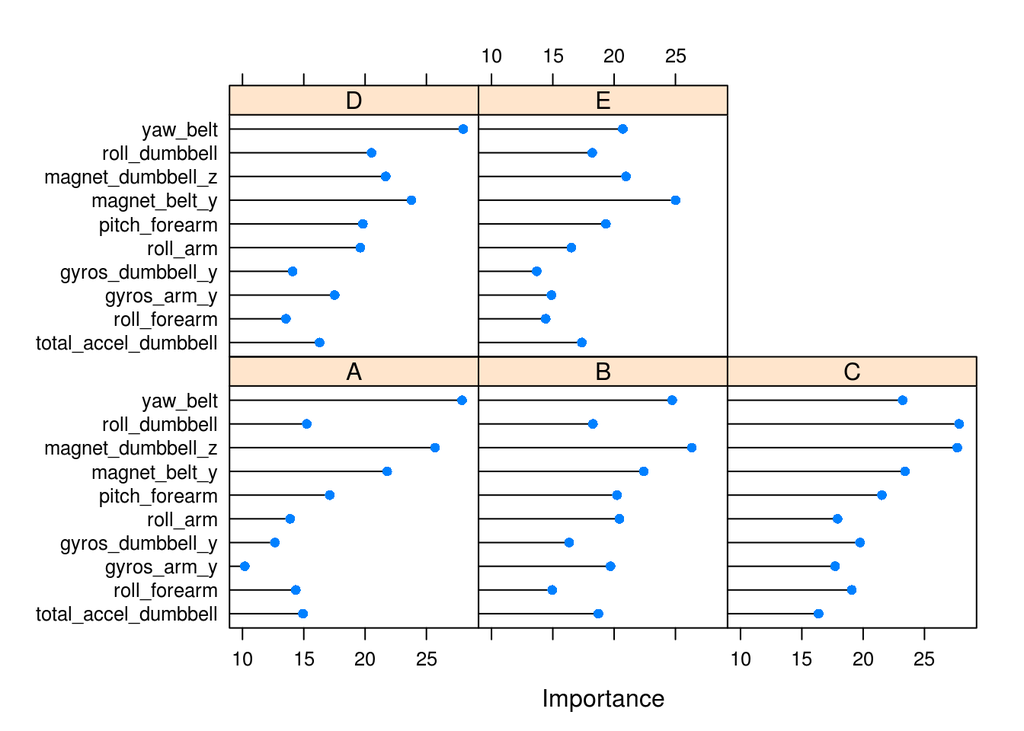

```r
plot(rfImp, top = 10)
```

## Testing the Model

Now we must estimate the quality of this model using the testing data set. First prepare the testing data:

```r
testing.clean <- testing[,vars.keep]
```

And now apply the predict function and look at the accuracy measures.

```r
library(caret)
test.predict <- predict(rfFit,testing.clean )
postResample(test.predict, testing.clean$classe)
```

```
##  Accuracy     Kappa
## 0.9928630 0.9909719
```

Very nice results on the testing data set. Lets look at the confusion matrix.

```r
confusionMatrix(test.predict, testing.clean$classe)
```

```
## Confusion Matrix and Statistics
##
##           Reference
## Prediction    A    B    C    D    E
##          A 1393    5    0    0    0
##          B    1  941    7    0    0
##          C    0    3  843   10    1
##          D    0    0    5  794    2
##          E    1    0    0    0  898
##
## Overall Statistics
##
##                Accuracy : 0.9929
##                  95% CI : (0.9901, 0.995)
##     No Information Rate : 0.2845
##     P-Value [Acc > NIR] : < 2.2e-16
##
##                   Kappa : 0.991
##  Mcnemar's Test P-Value : NA
##
## Statistics by Class:
##
##                      Class: A Class: B Class: C Class: D Class: E
## Sensitivity            0.9986   0.9916   0.9860   0.9876   0.9967
## Specificity            0.9986   0.9980   0.9965   0.9983   0.9998
## Pos Pred Value         0.9964   0.9916   0.9837   0.9913   0.9989
## Neg Pred Value         0.9994   0.9980   0.9970   0.9976   0.9993
## Prevalence             0.2845   0.1935   0.1743   0.1639   0.1837
## Detection Rate         0.2841   0.1919   0.1719   0.1619   0.1831
## Detection Prevalence   0.2851   0.1935   0.1748   0.1633   0.1833
## Balanced Accuracy      0.9986   0.9948   0.9913   0.9929   0.9982
```

We got ourselfs a very accurate model, on the training and test dataset.

## The prediction to submit.

Lets get and clean the prediction data set.

```r
vars.test<-names(data.test)
ignore.test<- c("problem_id",ignore )
vars.keep.test <-setdiff(vars.test, ignore.test)
data.test.clean <- data.test[,vars.keep.test]
```

And now we shall use the function provided in the submission webpage to export the files with the predictions.

```r
# Predictions
pred <- predict(rfFit,data.test.clean)

pml_write_files = function(x){
  n = length(x)
  for(i in 1:n){
    filename = paste0("./data/problem_id_",i,".txt")
    write.table(x[i],file=filename,quote=FALSE,row.names=FALSE,col.names=FALSE)
  }
}
pml_write_files(pred)
```

### References

- http://topepo.github.io/caret/index.html
- http://appliedpredictivemodeling.com/
- Ugulino, W.; Cardador, D.; Vega, K.; Velloso, E.; Milidiu, R.; Fuks, H. Wearable Computing: Accelerometers’ Data Classification of Body Postures and Movements. Proceedings of 21st Brazilian Symposium on Artificial Intelligence. Advances in Artificial Intelligence - SBIA 2012. In: Lecture Notes in Computer Science. , pp. 52-61. Curitiba, PR: Springer Berlin / Heidelberg, 2012. ISBN 978-3-642-34458-9. DOI: 10.1007/978-3-642-34459-6_6.
- http://groupware.les.inf.puc-rio.br/har
- http://onepager.togaware.com/